# Human Activity Recognition Devices Predict Correct Usage of Exerciser Equipment.

## Summary

Data [1] was use to evaluate accelerometer data from individuals performing 5 exercises either correctly of incorrectly. A training set was used to evaluate several machine learning models were to determine which one(s) give the best fit with the training set. A test set, which had been set aside, was then used to predict results based on the training set fit.

## Data Processing

#### R packages were loaded and cores were selected for parallel computing.

```r
library(caret)
library(rattle)
library(plyr)
library(doParallel)
registerDoParallel(cores=4)
```

#### Data was loaded from the R directory.

```r
trainingSet <- read.csv("pml-training.csv", sep = ",")
testingSet <- read.csv("pml-testing.csv", sep = ",")
dim(testingSet); dim(trainingSet)
```

```
## [1]  20 160
```

```
## [1] 19622   160
```

#### All variables that missing data are remove from training and test data sets.

```r
train1<-trainingSet[ , apply(trainingSet, 2, function(x) !any(is.na(x)))]
newTest<-testingSet[ , apply(testingSet, 2, function(x) !any(is.na(x)))]
diff<-!(colnames(train1) %in% colnames(newTest))
d<-diff[-93]
newTrain<-train1[c(-which(d))]
#### This shows that all variables in newTrain and newTest are the same except the activity factor.  Thus the variables are the same except for the 60th variable.
which(!(colnames(newTrain) %in% colnames(newTest)))
```

```
## [1] 60
```

#### Partitioning of training data.

The newTrain data set is further split to give another “train” and “test” set for further model evaluation without using the assigned newTest data set.

```r
inTrain = createDataPartition(y=newTrain$classe, p = 0.75, list=FALSE)
train = newTrain[ inTrain,]
test = newTrain[-inTrain,]
```

#### Create a tree of accelerometer data from a 59 variable subset of data.

```r
ptm <- proc.time()
modFit <- train(classe ~ ., method="rpart", data=train)
print(modFit$finalModel)
```

[output not shown]

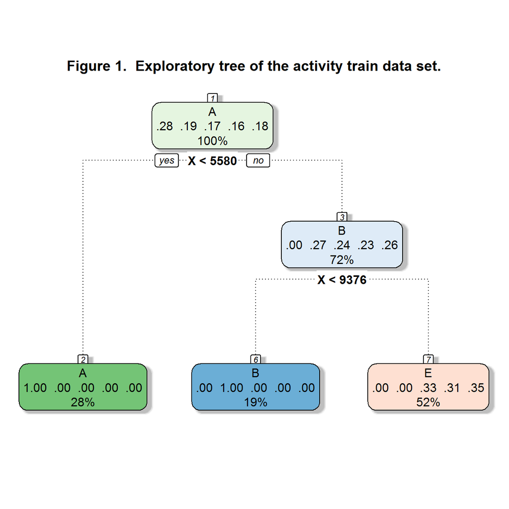

```r
par(mar=c(0,2,9,2))
fancyRpartPlot(modFit$finalModel, main="Figure 1.  Exploratory tree of the activity train data set.")
```

```r
proc.time() - ptm
```

```
##    user  system elapsed
##    9.59    0.41   76.75
```

#### The rainy forest model (rf) was evaluated the train and test data sets.

```r
ptm <- proc.time()
cvCtrl <- trainControl(method = 'repeatedcv', number = 5, repeats = 1)
modFit <- train(classe ~ ., data=train, method="rf", trControl = cvCtrl)
modFit
```

[output not shown]

```r
svmPredict<-predict(modFit, newdata = test[,-60])
confusionMatrix(svmPredict, test[,60])
```

```
## Confusion Matrix and Statistics
##
##           Reference
## Prediction    A    B    C    D    E
##          A 1395    0    0    0    0
##          B    0  949    0    0    0
##          C    0    0  855    0    0
##          D    0    0    0  804    0
##          E    0    0    0    0  901
##
## Overall Statistics
##
##                Accuracy : 1
##                  95% CI : (0.999, 1)
##     No Information Rate : 0.284
##     P-Value [Acc > NIR] : <2e-16
##
##                   Kappa : 1
##  Mcnemar's Test P-Value : NA
##
## Statistics by Class:
##
##                      Class: A Class: B Class: C Class: D Class: E
## Sensitivity             1.000    1.000    1.000    1.000    1.000
## Specificity             1.000    1.000    1.000    1.000    1.000
## Pos Pred Value          1.000    1.000    1.000    1.000    1.000
## Neg Pred Value          1.000    1.000    1.000    1.000    1.000
## Prevalence              0.284    0.194    0.174    0.164    0.184
## Detection Rate          0.284    0.194    0.174    0.164    0.184
## Detection Prevalence    0.284    0.194    0.174    0.164    0.184
## Balanced Accuracy       1.000    1.000    1.000    1.000    1.000
```

```r
proc.time() - ptm
```

```
##    user  system elapsed
##   55.85    0.59  314.30
```